# CEA补充分析结果

Fan

2020年4月29日

## CEA非线性情况的处理——RCS限制性立方样线条处理

进一步明确连续性变量CEA与HR的关系（是否为线性关系），确定CEA进入模型的最佳模式（将连续变量转为分类变量并不是很好的处理方式，将损失大量信息）。

CEA是否存在非线性的检验：由于非线性部分检验的p值小于0.05，可认为CEA与复发风险存在非线性关系

```
##                 Wald Statistics          Response: Surv(time, death)
##
##  Factor     Chi-Square d.f. P
##  CEA        433.98     2    <.0001
##   Nonlinear  36.27     1    <.0001
##  TOTAL      433.98     2    <.0001
```

那么CEA与复发风险之间的关系究竟如何。使用RCS策略处理连续性变量CEA，发现CEA=5是一个重要的拐点，大于5和小于5时，CEA与log(HR)都呈线性关系，只是斜率不同（如下图所示）。考虑将CEA分成两段处理（两段斜率不同的线性建模），重新建模，C-index有所提升，AUC表现也有改善（之前为0.73，目前可超过0.75）。

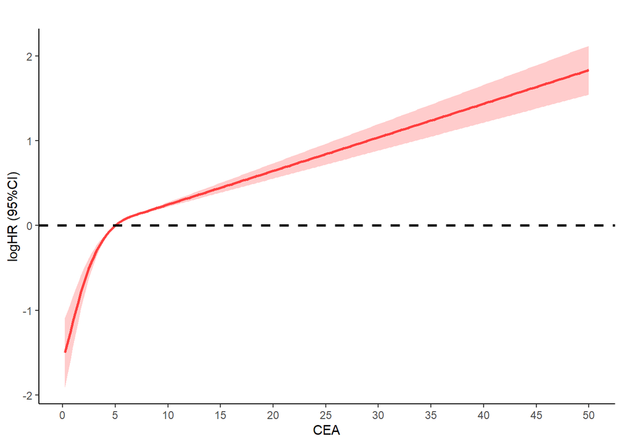

```
## concordant
##  0.7436794
```

## AUC

### 各时点AUC

此处将分别展示1、3、5年的AUC，发现3年和5年时刻的AUC较之前（之前的平均iAUC=0.73）明显更高，模型预测能力还不错。

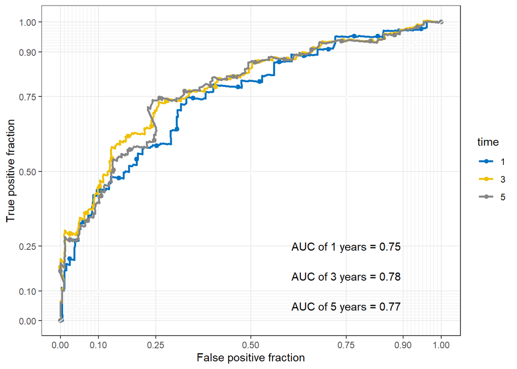

### 完整的时间依赖AUC

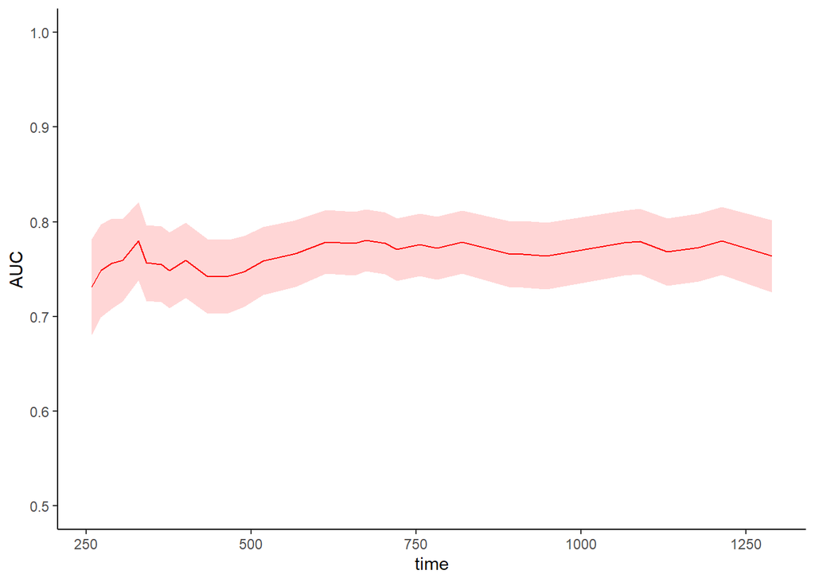

## DCA决策曲线

从决策曲线来看，TN_CEA（TN分期联合CEA）模型明显优于TN模型（净获益明显更大）

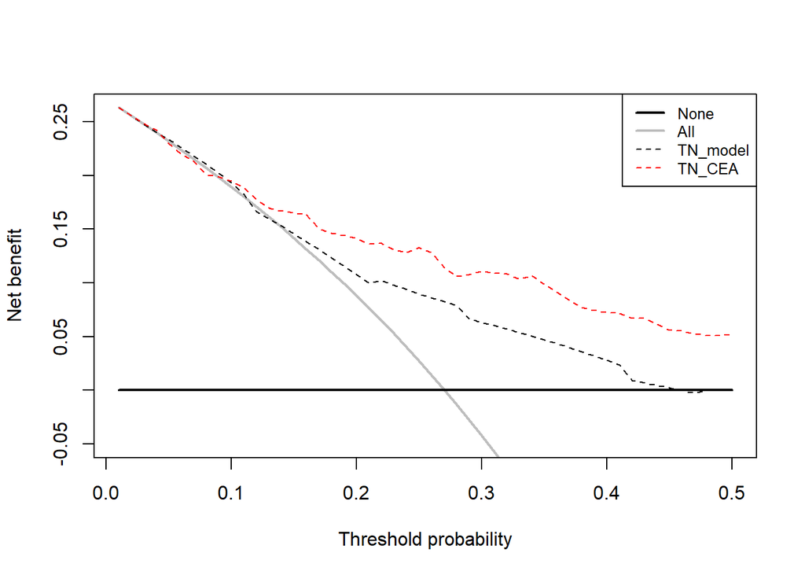

## 数据分布呈现

将模型的预测风险评分进行从小到大排序，展示各个病例对应的复发时间和是否出现复发(黑色点表示复发，红色点表示删失)、T分期、N分期、CEA情况

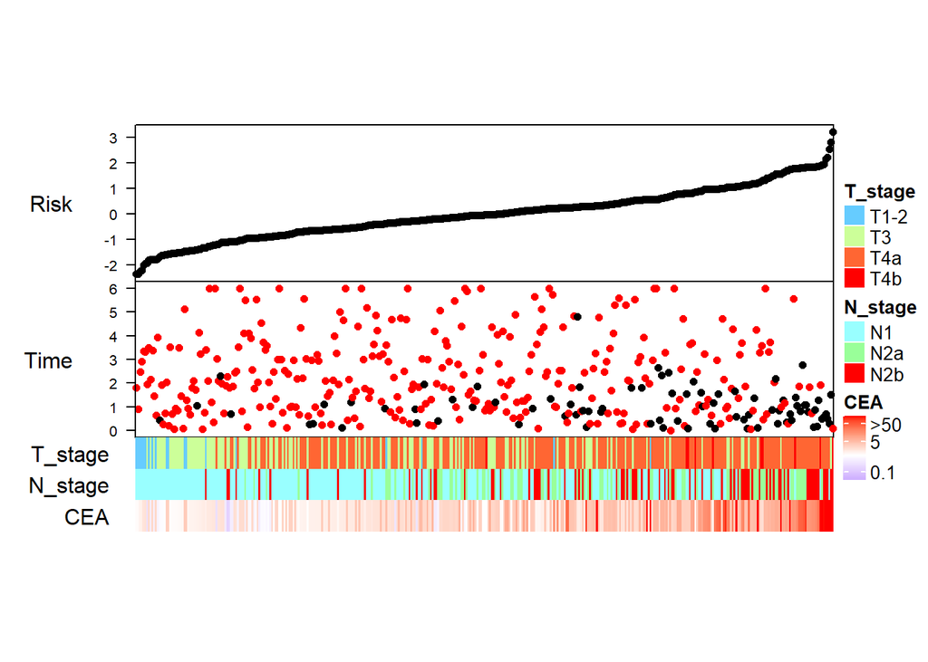

## 展示模型的校准曲线 calibration curve

从校准曲线的结果来看，模型的DFS和实际的DFS很接近，校准度偏差较小。

预测1年生存率的校准曲线：

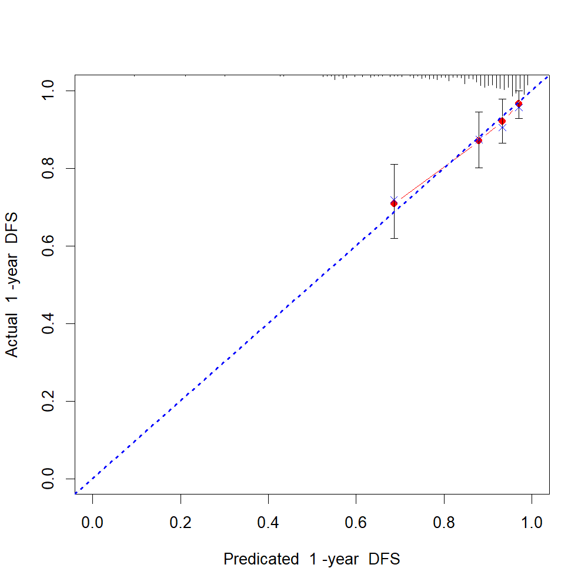

预测3年生存率的校准曲线：

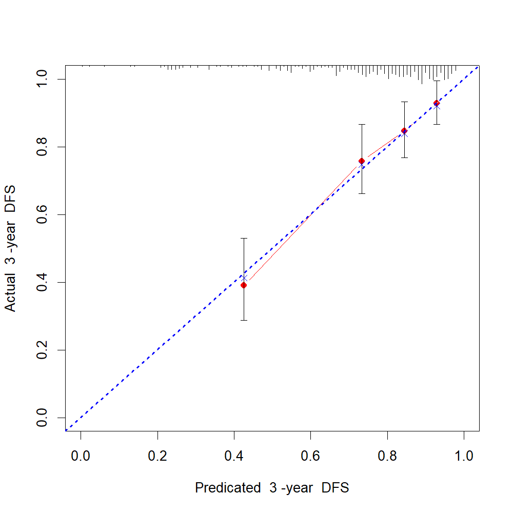

预测5年生存率的校准曲线：

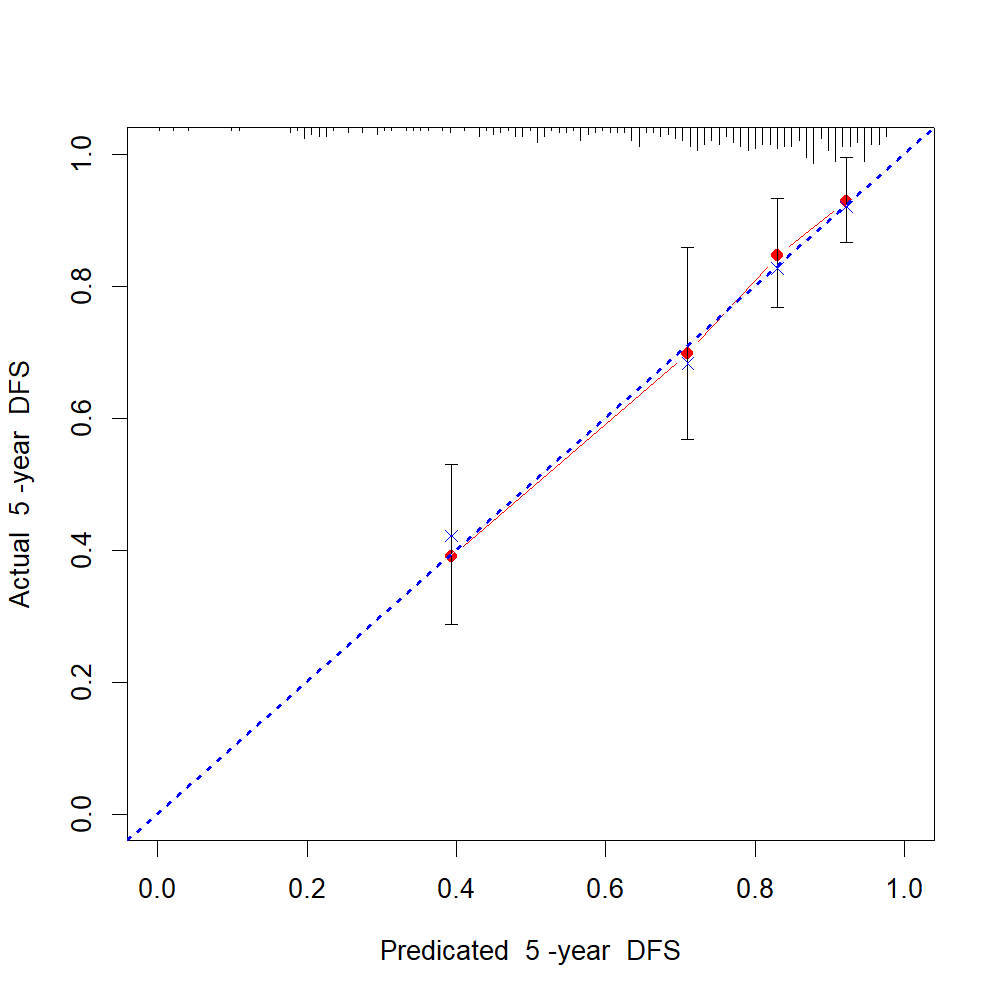